# Reading Data: APIs

## APIs

Application Programming Interfaces (APIs) - a defined method for asking for information from a computer

- Useful for getting data
- Useful for allowing others to run your model without a GUI (like Shiny)

Important for grabbing data from sources and putting your work into practice!

## APIs

Application Program Interface (API)

- set of subroutine definitions, communication protocols, and tools for building software
- Basically a protocol for computers to talk to one another
- Just need to understand the language!

Ex: [Census API](https://api.census.gov/data.html)

- Usually need to get a key (sometimes a username and password)

## APIs

Very few APIs are out there for R as compared to say python

- Some R packages exist such as `censusapi` (you should get your own key [here](https://api.census.gov/data/key_signup.html))

```r
library(censusapi)
apis <- listCensusApis()
head(apis)
```

```
##                          title     name vintage
## 90  ACS 1-Year Detailed Tables acs/acs1    2010
## 49  ACS 1-Year Detailed Tables acs/acs1    2011
## 196 ACS 1-Year Detailed Tables acs/acs1    2012
## 148 ACS 1-Year Detailed Tables acs/acs1    2013
## 255 ACS 1-Year Detailed Tables acs/acs1    2014
## 121 ACS 1-Year Detailed Tables acs/acs1    2015
##                                           url isTimeseries     temporal
## 90  https://api.census.gov/data/2010/acs/acs1           NA unidentified
## 49  https://api.census.gov/data/2011/acs/acs1           NA unidentified
## 196 https://api.census.gov/data/2012/acs/acs1           NA unidentified
## 148 https://api.census.gov/data/2013/acs/acs1           NA unidentified
## 255 https://api.census.gov/data/2014/acs/acs1           NA unidentified
## 121 https://api.census.gov/data/2015/acs/acs1           NA unidentified
##                                                                                                                                                                                                                                                                                                          …
## 90  The American Community Survey (ACS) is a nationwide survey designed to provide communities a fresh look at how they are changing. The ACS replaced the decennial census long form in 2010 and thereafter by collecting long form type information throughout the decade rather than only once every 1…
## 49  The American Community Survey (ACS) is a nationwide survey designed to provide communities a fresh look at how they are changing. The ACS replaced the decennial census long form in 2010 and thereafter by collecting long form type information throughout the decade rather than only once every 1…
## 196 The American Community Survey (ACS) is a nationwide survey designed to provide communities a fresh look at how they are changing. The ACS replaced the decennial census long form in 2010 and thereafter by collecting long form type information throughout the decade rather than only once every 1…
## 148 The American Community Survey (ACS) is a nationwide survey designed to provide communities a fresh look at how they are changing. The ACS replaced the decennial census long form in 2010 and thereafter by collecting long form type information throughout the decade rather than only once every 1…
## 255                                                                                                                                                                                                                                                                                                      …
## 121                                                                                                                                                                                                                                                                                                      …
##                  modified
## 90  2018-07-04 00:00:00.0
## 49  2018-07-04 00:00:00.0
## 196 2018-07-04 00:00:00.0
## 148 2018-07-04 00:00:00.0
## 255 2018-07-05 00:00:00.0
## 121 2018-07-05 00:00:00.0
```

## APIs

`getCensus()`

- makes an API call to a given Census API and returns a data frame
- most census APIs require (among other things)
  - name - API name given by Census (“acs5” or “timeseries/bds/firms”)
  - vintage - dataset year
  - vars - list of variable names to get
  - region - geography level to return, like state or county

## APIs

Follow vignette example of getting uninsured rates by income group using the Small Area Health Insurance Estimates API, which provides detailed annual state-level and county-level estimates of health insurance rates.

- name = sahie
- vintage is time for this api (time = 2016 will be used)
- vars/region we'll look at the list of available values

## APIs (List of vars)

```r
sahie_vars <- listCensusMetadata(name = "timeseries/healthins/sahie", type = "variables")
```

Partial list

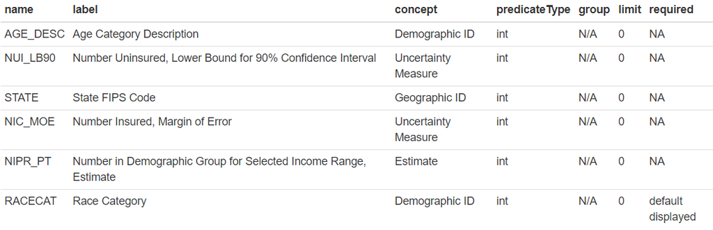

## APIs

Variables we'll get from that list

- IPRCAT: Income Poverty Ratio Category
- IPR_DESC: Income Poverty Ratio Category Description
- PCTUI_PT: Percent Uninsured in Demographic Group for Selected Income Range, Estimate
- NAME: Name of the geography returned (e.g. state or county name)

## APIs (List of Region option)

```r
listCensusMetadata(name = "timeseries/healthins/sahie", type = "geography")
```

```
##     name geoLevelId limit referenceDate requires wildcard
## 1     us        010     1    2015-01-01     NULL     NULL
## 2 county        050  3142    2015-01-01    state    state
## 3  state        040    52    2015-01-01     NULL     NULL
##   optionalWithWCFor
## 1              <NA>
## 2             state
## 3              <NA>
```

- us, county, or state can be requested

## APIs

Call some data (ask the api for it)

- uninsured rate by income group at the national level

```r
getCensus(name = "timeseries/healthins/sahie",
    vars = c("NAME", "IPRCAT", "IPR_DESC", "PCTUI_PT"),
    region = "us:*",
    time = 2016, key = "your_key_here")
```

```
##   time us          NAME IPRCAT                IPR_DESC PCTUI_PT
## 1 2016  1 United States      0             All Incomes     10.0
## 2 2016  1 United States      1      <= 200% of Poverty     17.0
## 3 2016  1 United States      2      <= 250% of Poverty     16.3
## 4 2016  1 United States      3      <= 138% of Poverty     17.4
## 5 2016  1 United States      4      <= 400% of Poverty     14.0
## 6 2016  1 United States      5 138% to 400% of Poverty     12.1
```

## APIs

Call some data (ask the api for it)

- uninsured rate by income group for each state

```r
sahie_states <- getCensus(name = "timeseries/healthins/sahie",
    vars = c("NAME", "IPRCAT", "IPR_DESC", "PCTUI_PT"),
    region = "state:*",
    time = 2016, key = "e267f117801b2ef741e54620602b0903c5f4d3c8")
head(sahie_states)
```

```
##   time state       NAME IPRCAT    IPR_DESC PCTUI_PT
## 1 2016    01    Alabama      0 All Incomes     10.8
## 2 2016    02     Alaska      0 All Incomes     15.5
## 3 2016    04    Arizona      0 All Incomes     11.9
## 4 2016    05   Arkansas      0 All Incomes      9.4
## 5 2016    06 California      0 All Incomes      8.4
## 6 2016    08   Colorado      0 All Incomes      8.6
```

## What Does `censusapi` Do?

Creates the correct call to the API (similar to examples we saw)

`constructURL <- function(name, vintage) {`  
`if (is.null(vintage)) {`  
`apiurl <- paste("https://api.census.gov/data", name, sep = "/")`  
`}`  
`else {`  
`apiurl <- paste("https://api.census.gov/data", vintage, name, sep = "/")`  
`}`  
`lastchar <- substr(apiurl, nchar(apiurl), nchar(apiurl))`  
`if (lastchar == "?" | lastchar == "/") {`  
`apiurl <- substr(apiurl, 1, nchar(apiurl) - 1)`  
`}`  
`apiurl`  
`}`

## API Access in R

Article [here](https://www.programmableweb.com/news/how-to-access-any-restful-api-using-r-language/how-to/2017/07/21) discusses accessing APIs generically with R

Same website gives a [list of APIs](https://www.programmableweb.com/category/all/apis)

## Implementing a Model in Production

Later: Need a way to make your model available to others

- Can write an API that accesses your model
- Hosted on a server or locally
- Not traditionally done in R but can be!

## Recap

Many sources of data

- flat delimited files
- Excel
- Databases
- APIs
- Web scraping (not covered here)

Need to know how to bring data in and manipulate it for analysis!